# CHAPTER A11

# 連続構造 - モーメント分配法

## A11.1 はじめに

モーメント分配法（Moment Distribution Method）は、ハーディ・クロス（Hardy Cross）教授によって考案された。*  
この手法は、シンプルかつ迅速であり、特に不静定次数が非常に高い連続構造の解法に適している。そこでは、多数の連立方程式を解くための通常の退屈な代数計算を避けることができる。さらに、この手法には、荷重を支持する構造物の実際の物理的挙動をより深く理解できるという利点がある。この事実は、一部の解法においては非常に曖昧になりがちである。

クロス法の手順は、一般に通常の解法とは逆である。通常の解法では、連続する特徴を取り除くことで、まず連続構造を静定構造にし、その後に元の連続性を満足させるような不静定量（余剰力）の値を求める。これに対し、クロス法では、構造物の各部材が特定の拘束された状態にあると仮定する。このようにして構造の連続性は維持されるが、構造の静力学的釣合いは崩れた状態からスタートする。その後、連続性と静力学の特定の法則に従って、構造物をその任意に仮定された拘束状態から段階的に解放していき、構造のすべての部分が真の平衡状態に達するまで処理を続ける。

クロス法の一般的な原理は、具体的な構造物を参照することで最もよく説明できる。  
図 A11.1 は、2スパン連続梁を示している。曲げモーメント図を求めることが要求されているとする。まず、各スパンの端部において回転が完全に拘束されていると任意に仮定する。選択した例では、端部 $A$ と $C$ は既に固定されているため、これらの点に新たな拘束を追加する必要はない。節点 $B$ は固定されていないため、この節点は回転できないように仮想的にロックされていると考える。そして、仮定された条件下において各部材の端部に生じる曲げモーメントを決定する。図 A11.2 は、この状態におけるモーメント曲線を示している。（固定端モーメントの計算と公式については、以降のセクションを参照のこと）。図 A11.3 は、この仮定された条件下におけるたわみ曲線の概形を示している。節点 $B$ における構造物の連続性は維持されていることがわかる。しかし、図 A11.2 のモーメント曲線から、支点 $B$ の上部における梁の内部曲げモーメントは静力学的に釣り合っていないことがわかる。具体的には、 $270$ の不釣合いが存在する。次のステップは、この節点を静力学的に釣り合わせることである。そのため、この節点を仮想的なロック状態から解放（アンロック）すると、明らかに節点 $B$ は平衡が確立されるまで回転する（図 A11.4 を参照）。すなわち、支点 $B$ において $270$ に等しい抵抗モーメントが2つの梁に発生するまで回転する。

ここで問題となるのは、このモーメントがそれぞれの梁によってどれだけ分担されるかという点である。節点 $B$ における2つの梁へのこの分配比率を決定する物理的条件は、両方の梁の $B$ 端が同じ角度だけ回転しなければならないという事実である。したがって、不釣合いモーメント $270$ は、共通の角度にわたって $B$ 端の回転に抵抗する各部材の能力（剛性）に比例して、2つの梁の間で分配される。梁のこの物理的特性を「剛性（stiffness）」と呼ぶ。ここで、梁 $BA$ と $BC$ の剛性係数が、図 A11.4 に示すように、 $BC$ に $162$ 、 $BA$ に $-108$ 分配されるような値であると仮定する（剛性係数については、以降のセクションで議論する）。

再び図 A11.4 を参照すると、たわみ曲線が節点 $B$ 上で回転するとき、それは $A$ および $C$ にある梁の他端を回転させようとする。しかし、これらの節点は固定されているため、 $A$ および $C$ におけるこの回転は阻止され、結果として $A$ および $C$ にモーメントが発生する。節点 $B$ の回転によって $A$ および $C$ に生じるこれらのモーメントを「到達モーメント（carry-over moments）」と呼ぶ。たわみ曲線の明らかな曲率（図 A11.4）に示されているように、到達モーメントは、回転端における分配モーメントとは反対の符号を持つ。分配モーメントに対する到達モーメントの比率は「到達率（carry-over factor）」と呼ばれ、梁の物理的特性および他端の拘束度によって決まる（到達率については以降のセクションで議論する。断面が一定で他端が固定されている梁の場合、到達率は $-1/2$ である）。図 A11.4 では、到達率を $-1/2$ と仮定しており、これにより $A$ および $C$ にそれぞれ $54$ および $-81$ の到達モーメントが発生する。最終的な端部モーメントを得るために、図 A11.4 に示すように、元の固定端モーメント、分配された釣合いモーメント、および到達モーメントを足し合わせる。このようにして不静定モーメントが決定されれば、せん断力、反力、およびスパン内モーメントの問題は、静力学の問題として解くことができる。

## A11.2 用語の定義と導出

### 1. 固定端モーメント (Fixed-end moments):

「固定端モーメント」とは、部材の端部が回転に対して完全に固定されている場合に、その部材の端部に存在するモーメントを意味する。

### 2. 剛性係数 (Stiffness Factor):

部材の剛性係数は、その部材の一端に単位回転を生じさせるために加える必要のある偶力の大きさに比例する値であり、部材の両端は移動しない（並進しない）ものと仮定する。剛性係数の値は、偶力が加えられる端部とは反対側の端部の拘束度または固定度にある程度依存する。剛性係数の記号としては、文字 $K$ が使用される。

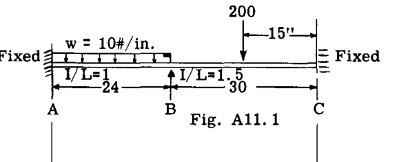

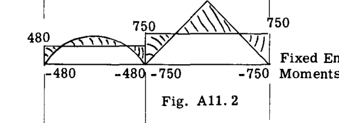

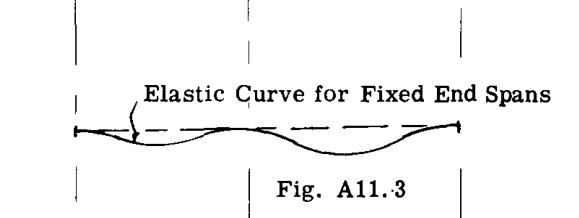

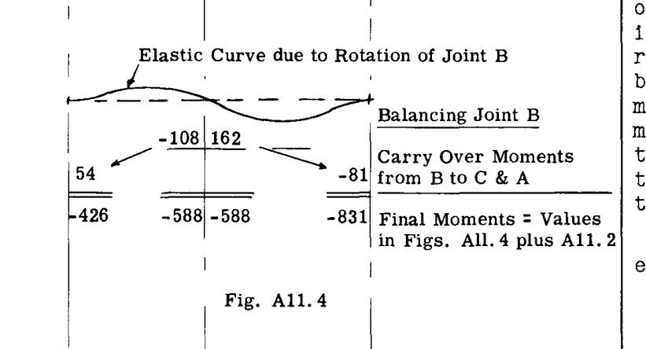

### 3. 到達率 (Carry-over Factor):

梁の一端が単純支持され、他端がある程度拘束されている場合、単純支持端にモーメントを加えると、拘束端にモーメントが発生する。到達率とは、拘束端におけるモーメントと単純支持端におけるモーメントの比である。軸方向荷重のない等断面（プリズマティック）梁の場合、遠端が固定されているときの到達率は $0.5$ である。到達率を表すには文字 $C$ が使用される。

### 4. 分配率 (Distribution Factor):

2つ以上の部材が剛結されている節点にモーメントが作用する場合、各部材の分配率は、作用したモーメントのうちその部材が抵抗する割合を示す。任意の部材の分配率は記号 $D$ で表され、次のようになる。

$$D = \frac{K}{\sum K}$$

ここで、 $K$ は特定の部材の剛性係数であり、 $\sum K$ はその節点に集まるすべての部材の $K$ 値の総和である。任意の節点における $D$ 値の総和は $1$ に等しくなければならない。

### 5. 符号の定義 (Sign Convention):

航空機構造でよく見られるように、多くの問題において部材がすべての方向から節点に集まるため、モーメントに関する従来の符号の定義は、モーメント分配法を適用する際に混乱を招く可能性がある。本書では、以下の符号の定義を使用する： - 部材の端部に作用する時計回りのモーメントを正（ $+$ ）とし、反時計回りのモーメントを負（ $-$ ）とする。  
- したがって、節点を時計回りに回転させようとするモーメントは負（ $-$ ）となる。  
モーメント分配法によって不静定の連続モーメントを決定する際には、上記で採用した符号の定義を使用するが、部材自体の設計に進む前に、従来の符号に変換する必要があることを理解しておく必要がある。

#### 端部モーメントの符号の定義の図解

##### 例 1

横荷重を受ける固定端梁。

**従来の符号**: 底面繊維に引張を生じる曲げモーメントを正とする。  
**採用された符号**: 部材の端部を時計回りに回転させようとするモーメントを正とする。

##### 例 2

固定端梁の支点の沈下。

##### 例 3

構造の節点における外力モーメント。

**採用された符号**: 節点を反時計回りに回転させようとするモーメントを正とする。

## A11.3 固定端モーメントの計算

固定端モーメントは静的に不静定であるため、これらを解くためには連続性の法則から追加の事実を得る必要がある。本書では、固定端モーメントの計算、およびモーメント分配法で使用されるその他の用語を説明するために、モーメント面積定理（Area-Moment Method）を使用する（参照：A7章）。

以下のよく知られたモーメント面積法の原理または定理が使用される：

1. 梁のたわみ曲線上の任意の点 $A$ における、別の点 $B$ でのたわみ曲線の接線からの偏位（縦距）は、点 $A$ と $B$ の間における $\frac{M}{EI}$ 図の面積の、点 $A$ のまわりのモーメントに等しい。
2. 梁のたわみ曲線上の2点 $A$ と $B$ の間のたわみ角（傾斜角）の変化は、2点 $A$ と $B$ の間における $\frac{M}{EI}$ 図の面積に等しい。

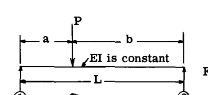

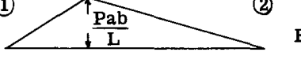

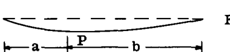

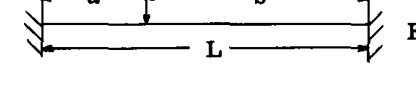

端部 (1) と (2) の間のたわみ曲線のたわみ角の変化はゼロであるため、固定端梁に適用される定理 (2) は以下のように言い換えることができる。

モーメント図の面積の総和はゼロに等しくなければならない。そして定理 (1) から、任意の点に関するモーメント図の面積の静力学モーメントはゼロに等しくなければならない。式で表すと以下のようになる。

$$\sum M = 0 \quad \cdots\cdots\text{(1)}$$
$$\sum M x = 0 \quad \cdots\cdots\text{(2)}$$

断面が変化する梁の場合、固定の条件は次のようになる。

$$\int \frac{M dx}{EI} = 0$$
$$\int \frac{M x dx}{EI} = 0$$

$$M = \frac{Pab}{2} + \frac{M_1 L}{2} + \frac{M_2 L}{2} = 0 \quad \cdots\cdots\text{(3)}$$

また、式 (2) より、左端まわりの $M_x$ は、

$$M_x = \frac{Pab}{2} \cdot \frac{L+a}{3} + \frac{M_1 L}{2} \cdot \frac{L}{3} + \frac{M_2 L}{2} \cdot \frac{2L}{3} = 0 \quad \cdots\cdots\text{(4)}$$

任意の $a$ または $b$ の値に対する $M_1$ と $M_2$ の値は、式 (3) と (4) を解くことによって求めることができる。

表 A11.1 は、日常の設計および解析で遭遇するほとんどの荷重状態に対する梁の固定端モーメントの要約を示している。

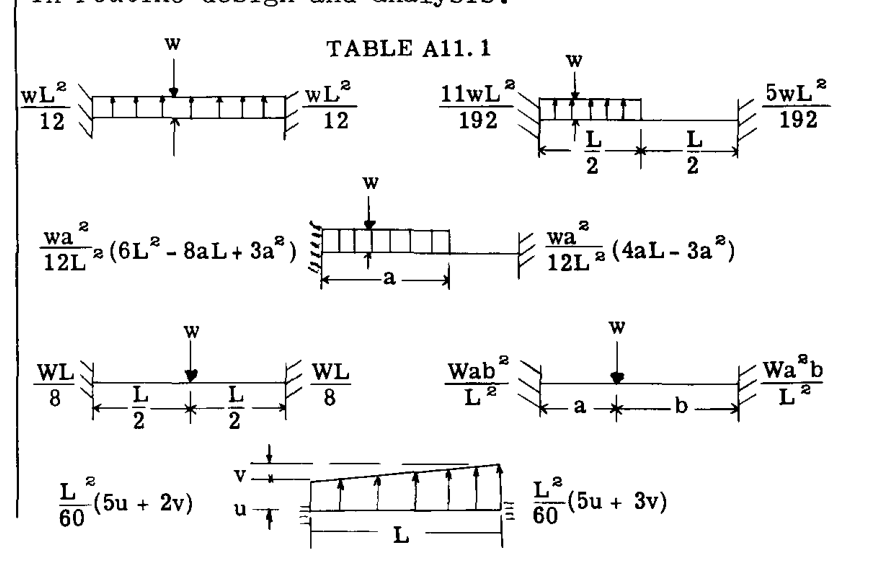

TABLE All. 1

## A11.4 剛性係数、到達率の導出

（これらの用語の定義については、A11.2ページを参照）。  
図 A11.13 の梁を考える。モールの定理（A7.12節を参照）により、AB線に対する点 A におけるたわみ曲線のたわみ角は、A と B の間で荷重として作用する $\frac{M}{EI}$ 曲線による、単純支持梁 AB の A におけるせん断力に等しい。

したがって、

$$\theta_A = - \frac{(ML \times 1/3)}{2EI} = - \frac{ML}{6EI} \quad \text{（正のせん断 ＝ 負のたわみ角）}$$
$$\theta_B = \frac{ML \times 2/3}{2EI} = \frac{ML}{3EI}$$

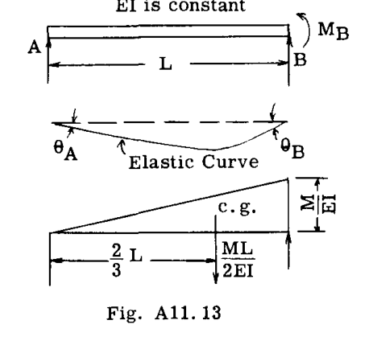

Fig. All. 13

ここで、 $\theta_B = 1$ （単位回転）とする。  
すると、 $1 = \frac{ML}{3EI}$ 、または $M_B = \frac{3EI}{L} = \text{梁 } BA \text{ の剛性係数}$ となる（図 A11.13）。B にモーメントを加えると、端部 A は自由に支持されているため、A にはモーメントが生じない。したがって、他端が自由に支持されている梁の到達率は明らかにゼロである。図 A11.14 の梁を考える。端部 A が完全に固定されているため、A におけるたわみ曲線のたわみ角はゼロである。

$$\theta_A = \frac{M_B L}{2EI} \cdot 1/3 + \frac{M_A L}{2EI} \cdot 2/3 = 0$$

または、

$$M_A = - \frac{M_B}{2}$$

したがって、他端が固定されている梁の到達率は $1/2$ である。従来のモーメント符号を使用すると、到達モーメントは上記の式に示されるように反対の符号になる。しかし、採用した符号の定義では、図 A11.14 に示すたわみ曲線の形状を観察すると、到達モーメントの符号は近端の回転モーメントと同じ符号であることがわかる。すなわち、部材の各端部に作用するモーメントは同じ方向であり、したがって同じ符号となる。

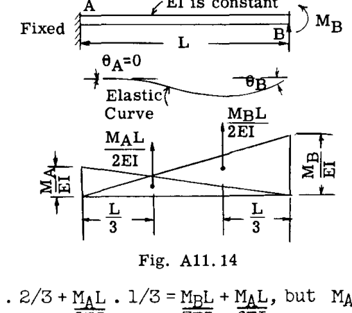

Fig. All. 14

$$\theta_B = \frac{M_B L}{2EI} \cdot 2/3 + \frac{M_A L}{2EI} \cdot 1/3 = \frac{M_B L}{3EI} + \frac{M_A L}{6EI}$$

しかし、 $M_A = - \frac{M_B}{2}$ である。  
したがって、

$$\theta_B = \frac{M_B L}{3EI} - \frac{M_B L}{12EI} = \frac{M_B L}{4EI}$$

$\theta_B = 1$ （単位回転）とすると、 $M_B = \frac{4EI}{L} = \text{梁 } BA \text{ の剛性係数}$ となる（図 A11.14）。

この梁の剛性係数と図 A11.13 の剛性係数を比較すると、他端が自由に支持されている梁の剛性係数は、他端が固定されている梁の剛性係数の $3/4$ であることがわかる。さらに、一方のケースでは到達率がゼロであり、他方のケースでは $1/2$ である。したがって、これら2つの値は、梁の他端の拘束度または固定度にある程度依存することが明らかである。

## A11.5 梁の他端の固定度 (F) による剛性および到達率の一般式

図 A11.14 の梁において、端部 A は完全に固定されていると仮定されていたため、固定度 $F$ は $1$ であった。その結果、以下が得られた。

$$M_B = \frac{4EI\theta_B}{L} \quad \text{および} \quad M_A = - \frac{2EI\theta_B}{L}$$

ここで、 $\theta_B = 1$ とし、簡単のために $\frac{EI}{L} = K$ とする。  
すると、

$$M_B = 4K$$
$$M_A = -2K$$

同様に、図 A11.13 の梁の結果からは以下が得られる。

$$M_B = 3K$$
$$M_A = 0$$

図 A11.15 および図 A11.16 は、これらの結果を示している。図 A11.17 は、端部 A における固定度が $F$ である一般のケースを示している。図 A11.15 と図 A11.17 の違いは、端部 A におけるたわみ角は変化しているが、端部 B におけるたわみ角 $\theta_B$ は同じままである点である。

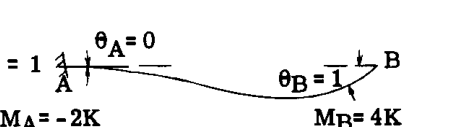

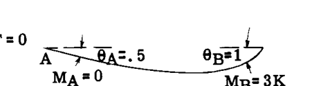

梁 A11.15 から A11.17 に変更したときの端部 A におけるモーメントの変化は、

$$2K - 2KF = 2K(1-F)$$

である。 $\theta_B$ は同じ値に保たれているため、端部 A におけるモーメント変化の半分が端部 B に現れるが、符号は反対になる。すなわち、

$$M_B = 4K - \frac{1}{2} \cdot 2K(1-F) = 3K + KF = K(3+F) = \frac{EI}{L}(3+F)$$

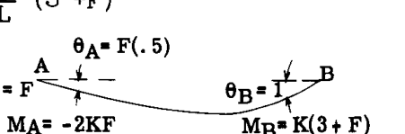

Fig. All. 17

したがって、等断面の梁の剛性係数の一般式は、

$$\frac{EI}{L}(3+F)$$

に等しい。B から A への到達率は、

$$M_A = - \frac{2KF}{K(3+F)} = - \frac{2F}{3+F}$$

となり、これは固定度 $F$ に対する到達率の一般式である。

## A11.5a 例題

「クロス」法の実際の仕組みを明確に理解するために、読者は以下の簡単な問題の詳細な解法を追うことをお勧めする。これらの問題では、各スパンの慣性モーメントは一定とされ、すべての節点は移動しないものと仮定されている。変化する $I$ や節点の移動を伴う問題については、後で検討する。

### 例題 1

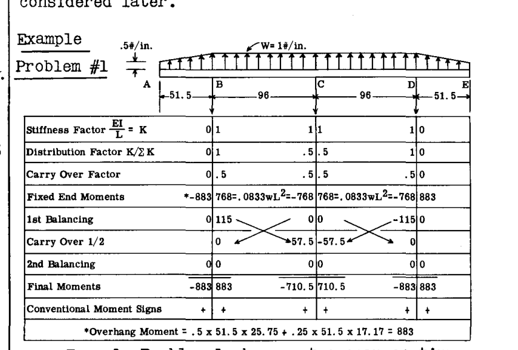

Example Problem #1

例題1は、張出し端を持つ2スパン連続梁を示している。まず、すべての節点 $B$ 、 $C$ 、 $D$ が回転に対してロックされている、あるいは梁 $BC$ と $CD$ が任意に固定端状態にあると仮定する。

解法の最初の行は、各梁の剛性係数を示している。A11.5節から、剛性係数の一般式は $\frac{EI(3+F)}{L}$ であり、ここではすべての節点が固定されているとみなされるため、遠端の固定度 $F$ は $1$ に等しい。したがって、剛性係数 $K = \frac{EI(3+1)}{L} = \frac{4EI}{L}$ となる。各スパン $BC$ と $CD$ で $\frac{EI}{L}$ が同じであるため、必要なのは相対値だけであることから、剛性係数は $1$ と書かれている。片持ち梁 $BA$ の剛性はゼロである。

2行目は、各節点における部材分配率 $D = \frac{K}{\sum K}$ を示している。例えば、節点 $B$ において、 $BA$ への分配率は $\frac{0}{(1+0)} = 0$ 、 $BC$ への分配率は $\frac{1}{(1+0)} = 1$ となる。節点 $C$ において、 $CB$ への分配率は $\frac{1}{(1+1)} = 0.5$ であり、 $CD$ に対しても同様に $0.5$ となる。

3行目は到達率を示している。A11.5節より、遠端が固定、すなわち各部材に対して $F = 1$ と仮定すると、到達率 $C = \frac{2F}{(3+F)} = \frac{2 \times 1}{(3+1)} = 0.5$ となる。

4番目の横行に示す次のステップは、固定端モーメントの計算である。モーメントの符号は、採用した符号の定義に従う。すなわち、部材の端部を時計回りに回転させようとする内部抵抗モーメントを正とする。

1サイクルのモーメント分配法が完了し、これは釣り合わせるものや到達するものがなくなるまで、言い換えればすべての仮想的な拘束が取り除かれ、構造物がその真の平衡状態に達するまで繰り返される。

2サイクル目を継続するために、節点 $B$ に戻り、再び仮定されたロック状態から解放する。点 $C$ からの到達モーメントがゼロであったため、不釣合いはなく、したがって分配または到達するものはない。点 $C$ に進み、節点を解放すると、 $57.5$ と $-57.5$ の到達モーメントの下で釣り合っていることがわかる。したがって、分配釣合いモーメントはゼロである。節点 $D$ も同様に、 $C$ からの到達モーメントがゼロであるため、釣り合っている。これで、すべての節点が平衡状態にあるため、回転させることなくすべての節点を解放できる。最終的なモーメントを得るために、元の固定端モーメントに、すべての分配釣合いモーメントおよび到達モーメントを足し合わせる。

## A11.6 手順の一般的なまとめ

1. すべての計算は、構造物の図の上、またはその隣に書き留めるべきである。
2. 各部材の端部における剛性係数 $K$ を決定する。 $K = \frac{(3+F)EI}{L}$ であり、ここで $F$ は部材の遠端における固定度である。すべての部材が遠端で固定されていると仮定される場合、 $E$ を一定とすれば、 $K$ は $\frac{I}{L}$ に比例する。
3. 構造物の各節点における各部材の分配率 $D$ を決定する。 $D = \frac{K}{\sum K}$ 。
4. 各部材の端部における到達率 $C$ を計算する。 $C = \frac{2F}{(3+F)}$ 。したがって、遠端が固定されている梁（ $F = 1$ ）では $C = 1/2$ となる。遠端がピン支持されている梁（ $F = 0$ ）では $C = 0$ となる。
5. 要約表 A11.1 の式を使用して、与えられた横荷重または支持点変位に対する固定端モーメント（ $f$ ）を計算する。梁の端部を時計回りに回転させようとする端部モーメントが正のモーメントである（A11.2節を参照）。
6. 一度に1つの節点を取り上げ、それを仮定された固定状態から解放し、他のすべての節点はロックされたままとする。不釣合いモーメントが存在する場合は、その分配率 $D$ に従って、接続されている部材間に反対符号の逆モーメントを分配することにより、静力学的に釣り合わせる。
7. これらの分配された釣合いモーメントは、部材の遠端に、分配モーメントに到達率 $C$ を乗じた値に等しく、かつ分配モーメントと同じ符号の到達モーメントを生じさせる。すべての分配モーメントについて、これらの到達モーメントを遠端に記録する。
8. 望ましい精度が得られるまで、各節点の解放、分配、およびモーメントの到達の手順を繰り返し、分配の後に計算を終了する。任意の部材端における最終的なモーメントは、元の固定端モーメントと、すべての分配モーメントおよび到達モーメントの代数和に等しくなる。

### 例題 2

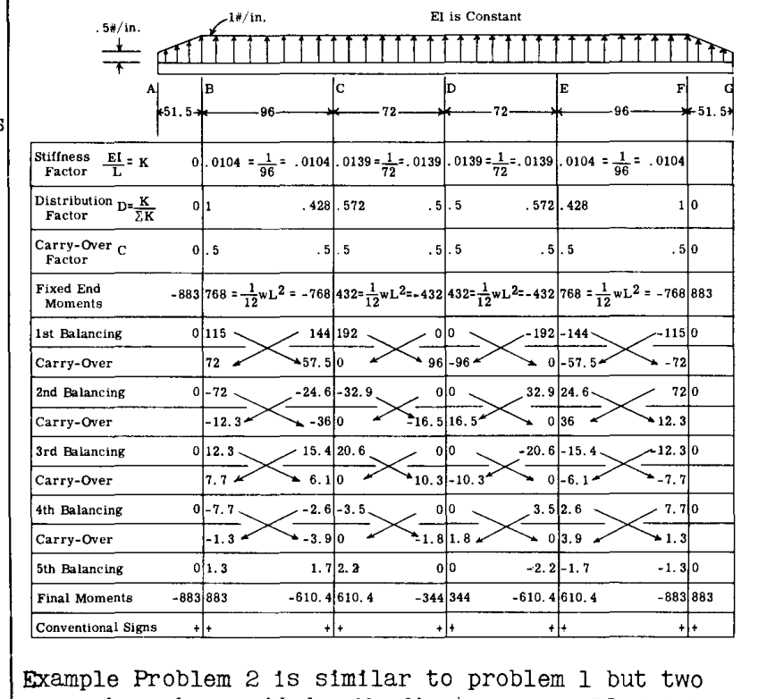

Example Problem #2

例題2は例題1と類似しているが、2つのスパンが追加されている。まず、すべての節点が回転に対してロックされていると仮定する。各スパンの剛性係数は、 $EI$ が一定であるため、 $\frac{EI}{L}$ または $\frac{1}{L}$ に比例する。到達率は、前の例と同様に $1/2$ である。固定端モーメントは図に示すように計算される。節点 $B$ を解放すると、不釣合いモーメントは $-115$ である。 $1 \times 115$ を $BC$ に、 $0$ を $BA$ に分配することで、節点を釣り合わせる。節点 $C$ に進む。

そして、他のすべての節点は固定されたままで、ロックを解除する。不釣合いモーメントは $(-768 + 432) = -336$ である。 $.428 \times 336 = 144$ を $CB$ に、 $.572 \times 336 = 192$ を $CD$ に分配して釣り合わせる。節点 $D$ に進み、解放する。不釣合いモーメントはゼロであり、これは節点 $D$ が平衡状態にあることを意味するため、分配は不要である。節点 $E$ および $F$ に進み、同様の方法で釣り合わせる。分配されるモーメントは、構造と荷重の対称性により、節点 $B$ および $C$ の値と同じになるが、採用した符号の定義により符号は反対になる。次のステップは、分配された釣合いモーメントの $1/2$ に等しい到達モーメントである。この操作は表に明確に示されている。すべてのモーメントの値は、小数第1位まで示されている。これで最初のサイクルが完了した。2サイクル目は、再び節点 $B$ を解放することから始まる。節点が $72$ の到達モーメントによって不釣合いになっていることがわかる。 $-72 \times 1 = -72$ を $BC$ に、 $0$ を $BA$ に分配して、節点を釣り合わせる。節点 $C$ に進む。不釣合いモーメントは $57.5$ である。 $-57.5 \times .428 = -24.6$ を $CB$ に、残りの $-32.9$ を $CD$ に分配して釣り合わせる。節点 $D$ に進む。この節点には到達モーメントが釣り合っているため不釣合いはなく、したがって分配は不要である。節点 $E$ および $F$ に進み、同様の方法で処理する。

$$\frac{\Delta M_{cd} - 0.5 \Delta M_{dc}}{\Delta M_{cb} - 0.5 \Delta M_{bc}} = \frac{K_{cd}}{K_{cb}}$$

数値を代入する：

$$\text{剛性係数の比} = \frac{K_{cd}}{K_{cb}} = \frac{0.0139}{0.0104} = 1.34$$

したがって、分配は隣接する部材の $K$ 比に従っている。

### 簡略化された修正 - 例題 3

例題2に示されている解法は、その基本的一般形における「クロス」法を示している。一般法の多くの修正案が提示されており、その大部分は計算の一部またはサイクル数を省略することを目的としている。これらの修正は通常、隣接する部材によって与えられる固定度に関して、部材の剛性と到達率を表すためのかなり長い式を伴う。方法を最もシンプルな形に保つことが最善であると考えられており、これは記憶すべきことが非常に少ないことを意味し、多くの必要な公式や方程式を思い出すことなく、頻繁に使用することができる。

しかし、非常に理解しやすく記憶に残る、かつ計算量をかなり減らすことができるいくつかの非常にシンプルな修正がある。

例えば、例題2において、節点 $B$ と $F$ は実際には自由に支持されているため、回転が完全に自由な節点のロックとアンロックを続ける必要はない。同様に、構造と荷重の対称性により、構造の半分だけを解けばよい。対称性により、節点 $D$ は回転しないため、固定されているとみなすことができ、これによりこの節点の繰り返しのロックとアンロックが排除される。

例題2の2番目の解法は、例題3に示されている。以前と同様に、各節点がロックされていると仮定し、固定端モーメントを計算する。ここで、節点 $B$ を解放またはアンロックし、前の例題2で説明したように釣り合わせる。節点 $C$ に進む前に、 $B$ から $C$ へ、 $115 \times 1/2 = 57.5$ に等しい到達モーメントを到達させる。節点 $B$ はこれで、自由に回転できる状態、またはその自然な状態のままにされる。節点 $C$ に進み、アンロックする。不釣合いモーメントは $(-768 + 432 + 57.5) = -278.5$ であり、平衡には $278.5$ が必要である。このモーメントは、遠端 $D$ が固定されている $CD$ と、遠端 $B$ が自由に支持されている $CB$ の2つの梁の間で分配される。剛性係数は $\frac{(3+F)EI}{L}$ に等しい（A11.5節を参照）。

したがって、 $CD$ の剛性係数は、

$$\frac{(3+1)EI}{L} = \frac{4EI}{L}$$

となる。 $CB$ の剛性係数は、

$$\frac{(3+0)EI}{L} = \frac{3EI}{L}$$

となる。換言すれば、他端が自由に支持されている梁の剛性は、他端が固定されている場合の $3/4$ である。したがって、 $C$ における $CB$ の剛性係数は、

$$0.75 \times 0.0104 = 0.0078$$

となる。 $B$ は自由に回転できる状態に置かれているため、 $C$ から $B$ への到達率 $C$ はゼロである（A11.5節を参照）。

### 例題 3

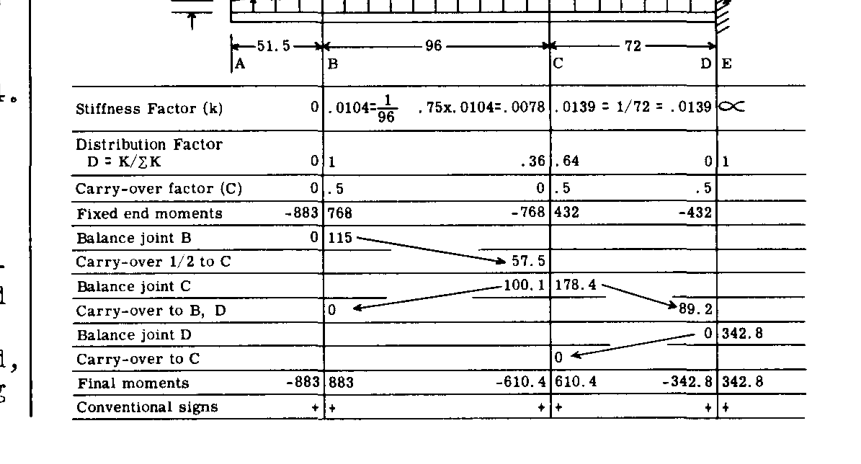

Example Problem #3

固定支点の剛性係数は無限大、すなわち剛な支点は回転に対して無限の抵抗を持つ。

## A11.4a 例題 4

例題4は例題2および例題3と類似しているが、 $D$ における支点が $50\%$ の固定度を持つと仮定されている点が異なる。したがって、この点における任意のモーメントの $50\%$ が、 $D$ における部材 $DC$ の回転を引き起こす。

支持金具によって支点上で連結されている連続翼梁では、梁が完全に連続しているとみなされ、また連続性の度合いが $50\%$ とされることが一般的である。例題4の解法1は詳細な解法である。唯一加えられた変更は、支持部 $E$ の剛性係数にあり、これは梁 $DC$ と等しく取られているため、この点における任意の不釣合いモーメントは、梁と支持部の間で等しく分割される。

解法2は、かなりの計算量を省略した修正解法である。したがって、節点 $B$ と $D$ は、一方が自由に支持され、他方が $50\%$ 固定されていることが確実に分かっているため、これらをロックおよびアンロックする必要はない。したがって、これらの節点を仮定された固定端状態から一度解放した後は、自然な状態のままにしておく。梁 $CB$ と $CD$ の剛性係数および到達率は、変更された端部条件を持つこれらの梁に対して決定されなければならない。

A11.5節の剛性および到達率の基本式を参照すると、 $CB$ の剛性係数は、他端 $B$ が固定されている場合の $3/4$ であり、到達率はゼロであることが容易にわかる。梁 $CD$ の場合、剛性は端部 $D$ が固定されている場合の $7/8$ であり、到達率は次のようになる。

$$\frac{2F}{3+F} = \frac{2 \times .5}{3 + .5} = .286$$

これらの修正により、解法は比較的少ないステップで進められる。したがって、解法2では、節点 $B$ がアンロックされる。 $-115$ の不釣合いモーメントは、 $115$ を $BC$ に分配することにより、静力学的に釣り合わされる。 $.5 \times 115 = 57.5$ の到達モーメントが、図に示すように $C$ に到達される。節点 $B$ はこれで、アンロックされた、または自由に回転できる状態のままにされる。次に、節点 $D$ がアンロックされる。不釣合いモーメントは $-432$ である。支点 $E$ は $50\%$ の固定度を与えるとみなされているため、 $216$ を $DC$ に、 $216$ を $E$ に分配して釣り合わせる。 $.5 \times 216 = 108$ の到達モーメントが $C$ に到達される。節点 $D$ はアンロックされた、またはその真の拘束状態のままにされる。次に、節点 $C$ がアンロックされる。不釣合いモーメントは、

### 解法 1

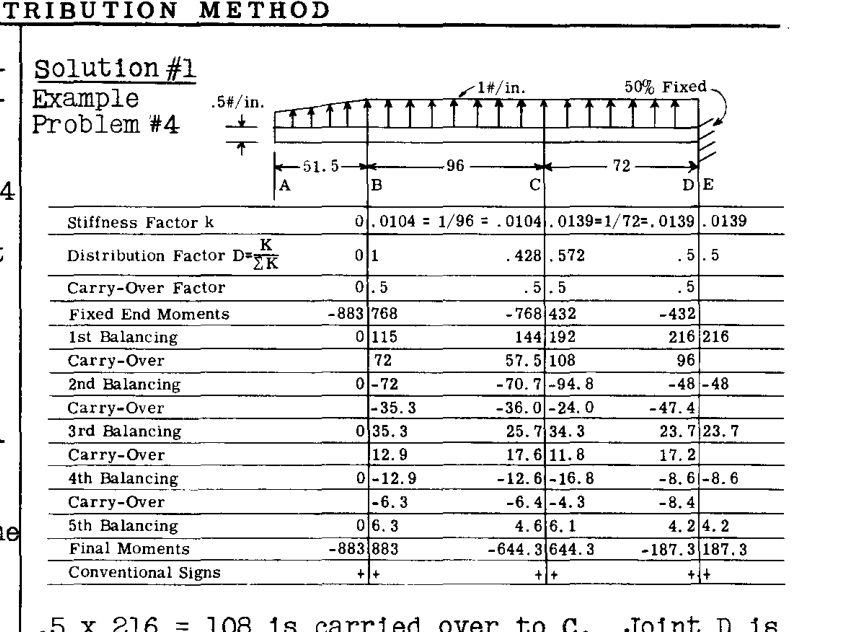

Solution #1

### 解法 2

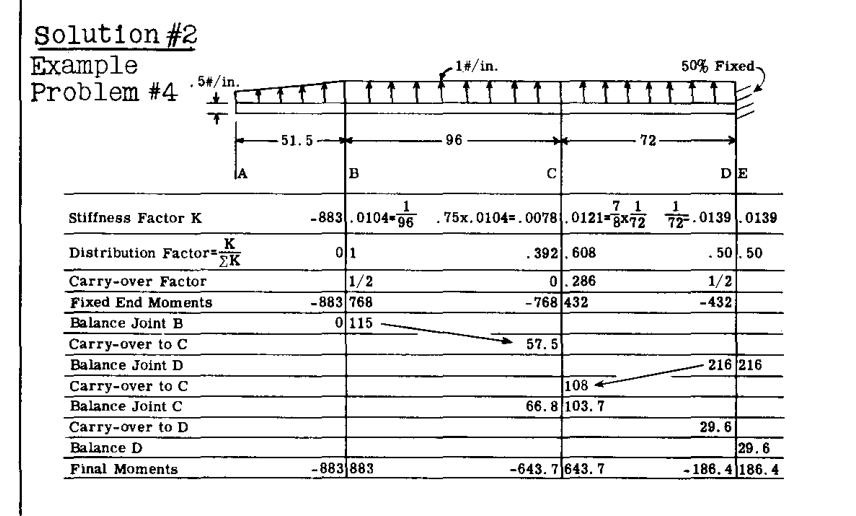

Solution #2

$$(-768 + 432 + 57.5 + 108) = -170.5$$

に等しく、平衡には $170.5$ が必要である。節点 $C$ は、 $.392 \times 170.5 = 66.8$ を $CB$ に分配し、残りの $103.7$ を $CD$ に分配することによって釣り合わされる。 $B$ への到達モーメントはゼロであり、 $D$ へは $103.7 \times .286 = 29.6$ に等しくなる。解法2における最終的なモーメントは、解法1とはわずかに異なっている。もし解法1にもう1サイクル追加されていれば、差異はかなり小さくなっていたであろう。

## A11.7 支点の沈下または変位を伴う連続梁

翼、昇降舵、方向舵の梁において、支持点は通常、翼の場合には支持ストラットやワイヤーの変形により、昇降舵や方向舵の梁の場合には安定板や垂直尾翼のたわみにより変位する。これらの梁が連続している場合、支持点のこの変位は、梁にさらなる曲げモーメントを引き起こす。モーメント分配法は、もちろん、この変位による追加のモーメントを求めるために使用できる。したがって、例題5は、連続梁の支持点の変位を伴う問題を説明する解法を示している。構造と荷重の対称性により、 $D$ におけるたわみたわみ角はゼロであるか、または梁は $D$ において固定されているとみなすことができる。

## A11.8 支持点の変位による固定端モーメント

図 A11.18 は、固定端梁を示している。支点 $B$ は、支持点 $C$ に対して距離 $d$ だけ変位している。部材が一定断面である場合、変曲点は梁の中点に位置し、 $M_B = - M_C$ となる。

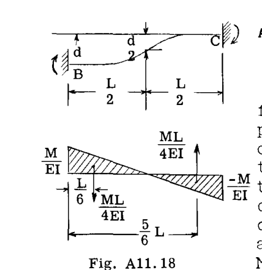

Fig. All. 18

または、

$$d = \frac{ML^2}{6EI}$$

したがって、

$$M = \frac{6EId}{L^2}$$

となり、これは横方向の支点沈下 $d$ による固定端モーメントの大きさである。

### 例題 5：支持点の変位を伴う連続梁

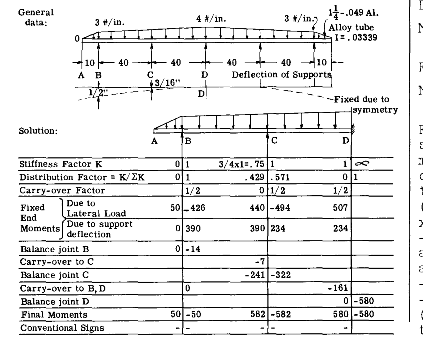

Example Problem #5

節点 $D$ 。慣性モーメントが一定で、スパンが一定であるため、梁の相対的な剛性係数は $1$ である。示されている解法では、梁は $B$ で自由に支持されているため、この節点は解放された後に自由に回転できるようになり、したがって梁 $CB$ の剛性係数は、 $B$ で完全固定されている場合と比較して、 $3/4 \times 1 = 3/4$ になる。

解法の最初のステップは、回転に対して固定された節点を仮定することであるため、一方の支持点を隣接する支持点に対して変位させると、回転に対して固定されていると仮定された端部にモーメントが生じることは明らかである。

固定端モーメントは横荷重と支持点変位の両方によるものであるため、解法表に記載されている値について以下に詳細に説明する。

#### 横方向梁荷重による固定端モーメント

スパン $BC$ の場合：

$$M_{bc} = \frac{40^2}{60}(5 \times 3 + 1) = 426 \text{ in. lb.}$$
$$M_{cb} = \frac{40^2}{60}(5 \times 3 + 1.5) = 440 \text{ in. lb.}$$

スパン $CD$ の場合：

$$M_{cd} = \frac{40^2}{60}(5 \times 3.5 + 1) = 494 \text{ in. lb.}$$
$$M_{dc} = \frac{40^2}{60}(5 \times 3.5 + 1.5) = 507 \text{ in. lb.}$$

#### 支持点の移動による固定端モーメント

A11.8節より、 $M = 6EId/L^2$ である。

スパン $BC$ の場合：

$C$ に対する $B$ の変位 ＝ $5/16$ インチ。したがって、

$$M_{bc} = M_{cb} = 6 \times 10,000,000 \times .03339 \times .3125 / 40^2 = 390 \text{ in. lb.}$$

スパン $CD$ の場合：

$$M_{cd} = M_{dc} = 6 \times 10,000,000 \times .03339 \times .1875 / 40^2 = 234 \text{ in. lb.}$$

これらの変位によるモーメントの符号については、A11.2節を参照のこと。固定端モーメントが決定されると、一般的な分配および到達プロセスは、解法表に示されているように進む。したがって、節点 $B$ において、不釣合いモーメントは $(50 - 426 + 390) = 14$ となる。 $-14 \times 1 = -14$ を $BC$ に、 $0$ を $BA$ に分配して釣り合わせる。 $.5 \times -14 = -7$ を $C$ に到達させる。節点 $C$ を考慮すると、不釣合いモーメントは $(440 + 390 + 234 - 494 - 7) = 563$ となる。 $-563 \times .571 = -322$ を $CD$ に、 $-563 \times .429 = -241$ を $CB$ に分配して釣り合わせる。 $.5 \times -322 = -161$ を $D$ に到達させる。節点 $D$ において、不釣合いモーメントは $(507 + 234 - 161) = 580$ となる。これは、 $DC$ にゼロを、固定支持に $-580$ を分配することによって釣り合わされる。